# Pathway and network analysis on GSE185657

BCB420 Assignment 3

Kevin Lu

2022-04-06

I’m using the same dataset from prior assignments, [“Differential effect of SARS-CoV-2 spike glycoprotein 1 on human bronchial and alveolar lung mucosa models: Implications on pathogenicity.”](https://www.ncbi.nlm.nih.gov/geo/query/acc.cgi?acc=GSE185657), published December 13, 2021. The corresponding publication can be found on GEO and in the references.

This experiment compares the expression response of human alveolar and bronchial cells to SARS-CoV-2 spike protein through RNA sequencing. Figure 1 from the paper shows the experimental design.

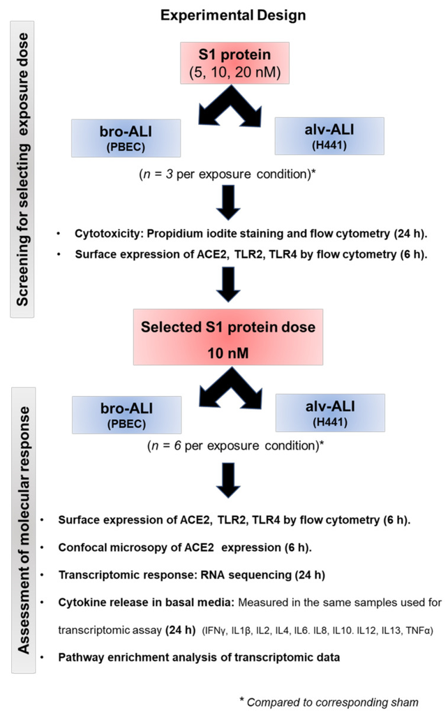

Figure 1. Experiment design. Rahman et al, 2021.

## Non-thresholded Gene set Enrichment Analysis

I will be using GSEA 4.1.0 from Docker image `risserlin/em_base_image:version_with_bioc_3_13` per lectures and a prior homework. I will be using the current April release of a geneset from the Gary Bader lab for enrichment analysis, containing GO biological processes and pathways but no IEA, [`Human_GOBP_AllPathways_no_GO_iea_April_01_2022_symbol.gmt`](https://download.baderlab.org/EM_Genesets/current_release/Human/symbol/Human_GOBP_AllPathways_no_GO_iea_April_01_2022_symbol.gmt)

This geneset uses HGNC symbols, so construct the ranked list for GSEA accordingly.

```r
rnk <- output_hits[output_hits$gene != "" & !is.na(output_hits$gene),]
rnk$rank <- -log10(rnk$P.Value) * sign(rnk$logFC)
# See https://software.broadinstitute.org/cancer/software/gsea/wiki/index.php/Data_formats#Ranked_Gene_Lists
write.table(rnk[,c("gene", "rank")], "GSEA_GSE185657.rnk", sep="\t", quote=FALSE, row.names=FALSE, col.names=FALSE)
```

The following commands were run in a shell due to instabilility with RStudio in the Docker image used. The parameters match that used in lectures and the prior homework.

```
host$ docker run --rm -it --user=rstudio -v $(pwd):/home/rstudio/projects risserlin/em_base_image:version_with_bioc_3_13 bash
rstudio@container$ cd ~/GSEA_4.1.0
rstudio@container$ ./gsea-cli.sh GSEAPreRanked -gmx ../projects/Human_GOBP_AllPathways_no_GO_iea_April_01_2022_symbol.gmt -rnk ../projects/GSEA_GSE185657.rnk -collapse false -nperm 1000 -scoring_scheme weighted -rpt_label A3 -plot_top_x 20 -rnd_seed 12345 -set_max 200 -set_min 15 -zip_report false -out ../projects/ > ../projects/gsea_output
```

### Enrichment results summary

All results have been uploaded to [GitHub](https://github.com/bcb420-2022/Kevin_Lu/tree/main/A3.GseaPreranked.1649192025218) with the [main summary here](https://github.com/bcb420-2022/Kevin_Lu/blob/main/A3.GseaPreranked.1649192025218/index.html). They are transcribed below.

312 gene sets are significantly upregulated at nominal pvalue < 5%. Top results:

1. HALLMARK_INTERFERON_ALPHA_RESPONSE (MSIGDB)
2. INTERFERON ALPHA BETA SIGNALING (REACTOME)
3. HALLMARK_INTERFERON_GAMMA_RESPONSE (MSIGDB)
4. DEFENSE RESPONSE TO SYMBIONT (GOBP)
5. DEFENSE RESPONSE TO VIRUS (GOBP)

350 gene sets are significantly downregulated at nominal pvalue < 5%. Top results:

1. ELECTRON TRANSPORT CHAIN: OXPHOS SYSTEM IN MITOCHONDRIA (WIKIPATHWAYS)
2. EUKARYOTIC TRANSLATION ELONGATION (REACTOME)
3. SELENOCYSTEINE SYNTHESIS (REACTOME)
4. FORMATION OF A POOL OF FREE 40S SUBUNITS (REACTOME)
5. CYTOPLASMIC RIBOSOMAL PROTEINS (WIKIPATHWAYS)

### Comparison with thresholded analysis from Assignment 2

GSEA found fewer significantly enriched gene sets than differentially-expressed genes found via thresholded analysis at the same p-value of 0.05, however, this is not an appropriate comparison as we are comparing gene sets to genes.

GSEA identified similar upregulated and downregulated pathways. The top hits for upregulated processes and pathways are also related to interferon signaling and the viral defence response, from two of the same data sources, Reactome and GO:BP. The top hits for downregulated processes and pathways concern metabolism and translation, from two of the same data sources, Reactome and WikiPathways. Some of the exact same processes and pathways appear in both lists.

This qualititative comparison is not straightforward as I am not comparing the full lists, just the top results. Furthermore, the data sources used are different. MSigDB is only part of the source used for GSEA. The results from g:Profiler also included one query with the entire differentially-expressed gene list, which has no equivalent in GSEA.

## Visualize your Gene set Enrichment Analysis in Cytoscape

I am using [Cytoscape 3.9.1](https://cytoscape.org/) for Windows 64-bit. Through the App Manager, I installed EnrichmentMap Pipeline Collection 1.1.0, which also installs the following apps (also cited in the references):

- clusterMaker2 2.2
- AutoAnnotate 1.3.5
- EnrichmentMap 3.3.3
- WordCloud 3.1.4
- NetworkAnalyzer 4.4.8
- FileTransfer 1.2
- cyChart 0.3.1

The following files were copied to a separate Windows folder, since I am running Docker in Windows Subsystem for Linux 2 and not mounting a Windows folder.

- `Human_GOBP_AllPathways_no_GO_iea_April_01_2022_symbol.gmt`
- `GSEA_GSE185657.rnk` produced by this notebook and input to GSEA
- the entire [`edb`](https://github.com/bcb420-2022/Kevin_Lu/tree/main/A3.GseaPreranked.1649192025218/edb) directory from GSEA output

The following command was executed in Cytoscape’s command line, with all specified paths prefixed with the absolute path of the containing Windows directory, backslashes escaped. This command and the specified thresholds were obtained from [these course notes](https://baderlab.github.io/Cytoscape_workflows/EnrichmentMapPipeline/Protocol2_createEM.html).

```
enrichmentmap build analysisType="gsea" gmtFile="Human_GOBP_AllPathways_no_GO_iea_April_01_2022_symbol.gmt" pvalue=0.05 qvalue=0.25 similaritycutoff=0.375 coefficients=COMBINED ranksDataset1="edb\\GSEA_GSE185657.rnk" enrichmentsDataset1="edb\\results.edb" filterByExpressions=false expressionDataset1="GSEA_GSE185657.rnk"
```

To make it more explicit from that command, the thresholds used are:

- pvalue = 0.05
- qvalue = 0.25
- similaritycutoff = 0.375
- coefficients = COMBINED

### Initial enrichment map

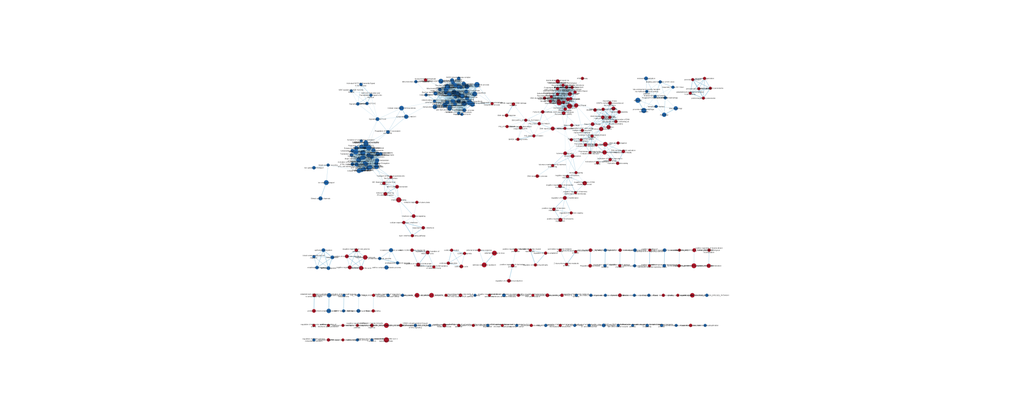

Initial Cytoscape enrichment map

**Legend:**

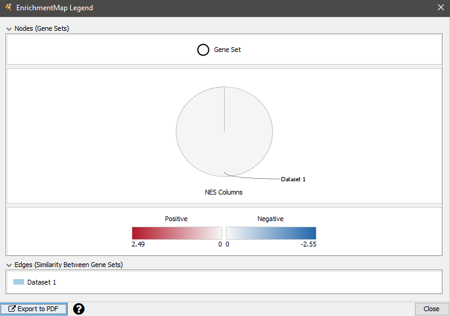

Legend for all enrichment maps

According to “Tools > Analyze Network,” treating it as an undirected graph, there are 309 nodes and 1609 edges.

## Interpretation and detailed view of results

### Dark matter

This comes from the slides.

```r
library(GSA)
capture.output(genesets <- GSA.read.gmt("Human_GOBP_AllPathways_no_GO_iea_April_01_2022_symbol.gmt"),file="gsa_load.out")
names(genesets$genesets) <- genesets$geneset.names
#get all the GSEA directories
gsea_directories <- list.files(pattern = "\\.GseaPreranked")
gsea_dir <- gsea_directories[1]
#get the gsea result files
gsea_results_files <- list.files(path = gsea_dir, pattern = "gsea_report_*.*.tsv")
#there should be 2 gsea results files
enr_file1 <- read.table(file.path(gsea_dir,gsea_results_files[1]),
                      header = TRUE, sep = "\t", quote="\"",
                      stringsAsFactors = FALSE,row.names=1)
enr_file2 <- read.table(file.path(gsea_dir,gsea_results_files[2]),
                      header = TRUE, sep = "\t", quote="\"",
                      stringsAsFactors = FALSE,row.names=1)
#get the genes from the set of enriched pathways (no matter what threshold)
all_enr_genesets<- c(rownames(enr_file1), rownames(enr_file2))
genes_enr_gs <- c()
for(i in 1:length(all_enr_genesets)){
  current_geneset <- unlist(genesets$genesets[which(genesets$geneset.names %in% all_enr_genesets[i])])
  genes_enr_gs <- union(genes_enr_gs, current_geneset)
}
FDR_threshold <- 0.001
#get the genes from the set of enriched pathways (no matter what threshold)
all_sig_enr_genesets<- c(rownames(enr_file1)[
  which(enr_file1[,"FDR.q.val"]<=FDR_threshold)],
rownames(enr_file2)[which(enr_file2[,"FDR.q.val"]<=FDR_threshold)])
genes_sig_enr_gs <- c()
for(i in 1:length(all_sig_enr_genesets)){
  current_geneset <- unlist(genesets$genesets[which(genesets$geneset.names %in% all_sig_enr_genesets[i])])
  genes_sig_enr_gs <- union(genes_sig_enr_gs, current_geneset)
}
genes_all_gs <- unique(unlist(genesets$genesets))
```

```r
length(genes_sig_enr_gs)
```

```
## [1] 1344
```

```r
if (!require(VennDiagram)) {
  install.packages("VennDiagram")
}
library(VennDiagram)
```

Dark matter overlaps

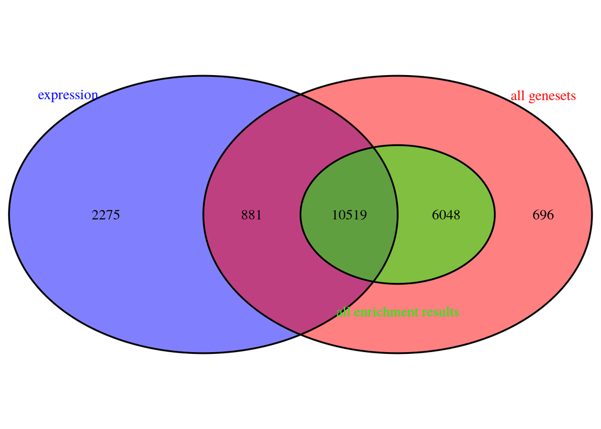

[output not shown]

```r
draw.triple.venn(
  area1=length(genes_all_gs),
  area2=length(genes_enr_gs),
  area3 =length(rnk$gene),
  n12 = length(intersect(genes_all_gs,genes_enr_gs)),
  n13=length(intersect(genes_all_gs,rnk$gene)),
  n23 = length(intersect(genes_enr_gs,rnk$gene)),
  n123 = length(intersect(genes_all_gs,intersect(genes_enr_gs,rnk$gene))),
  category = c(
  "all genesets",
  "all enrichment results",
  "expression"),
  fill = c("red","green","blue"),
  cat.col = c("red","green","blue")
)
```

Top dark matter genes

```r
genes_no_annotation <- setdiff(rnk$gene, genes_all_gs)
ranked_gene_no_annotation <- rnk[which(rnk$gene %in% genes_no_annotation),]
knitr::kable(ranked_gene_no_annotation[1:10,], type="html")
```

|  | Row.names | gene | logFC | AveExpr | t | P.Value | adj.P.Val | B | rank |
| --- | --- | --- | --- | --- | --- | --- | --- | --- | --- |
| 11213 | ENSG00000188707 | ZBED6CL | 1.687004 | 1.338325 | 3.665809 | 0.0011895 | 0.8315623 | -2.602529 | 2.924641 |
| 1492 | ENSG00000090372 | STRN4 | -6.626449 | 27.454873 | -3.549819 | 0.0015910 | 0.8315623 | -2.706156 | -2.798341 |
| 6511 | ENSG00000145337 | PYURF | -15.009661 | 124.198252 | -3.536024 | 0.0016467 | 0.8315623 | -2.718508 | -2.783375 |
| 12175 | ENSG00000210194 | MT-TE | -2.960040 | 6.106249 | -3.474690 | 0.0019187 | 0.8315623 | -2.773484 | -2.716985 |
| 6141 | ENSG00000141854 | MISP3 | -3.381942 | 6.542874 | -3.411846 | 0.0022427 | 0.8315623 | -2.829890 | -2.649231 |
| 14557 | ENSG00000285230 | RALY-AS1 | -3.366286 | 5.865339 | -3.389710 | 0.0023690 | 0.8315623 | -2.849771 | -2.625436 |
| 12854 | ENSG00000236432 | MFF-DT | 1.260441 | 1.795750 | 3.322266 | 0.0027979 | 0.8315623 | -2.910370 | 2.553169 |
| 12468 | ENSG00000224281 | SLC25A5-AS1 | -1.579658 | 1.870118 | -3.286434 | 0.0030554 | 0.8315623 | -2.942571 | -2.514925 |
| 9897 | ENSG00000175575 | PAAF1 | -8.386556 | 41.826509 | -3.265846 | 0.0032137 | 0.8315623 | -2.961073 | -2.493000 |
| 12496 | ENSG00000225269 | LINC00705 | 2.104523 | 2.212895 | 3.188359 | 0.0038831 | 0.8315623 | -3.030678 | 2.410816 |

heatmap of any significant genes that are not annotated to any of the pathways returned in the enrichment analysis.

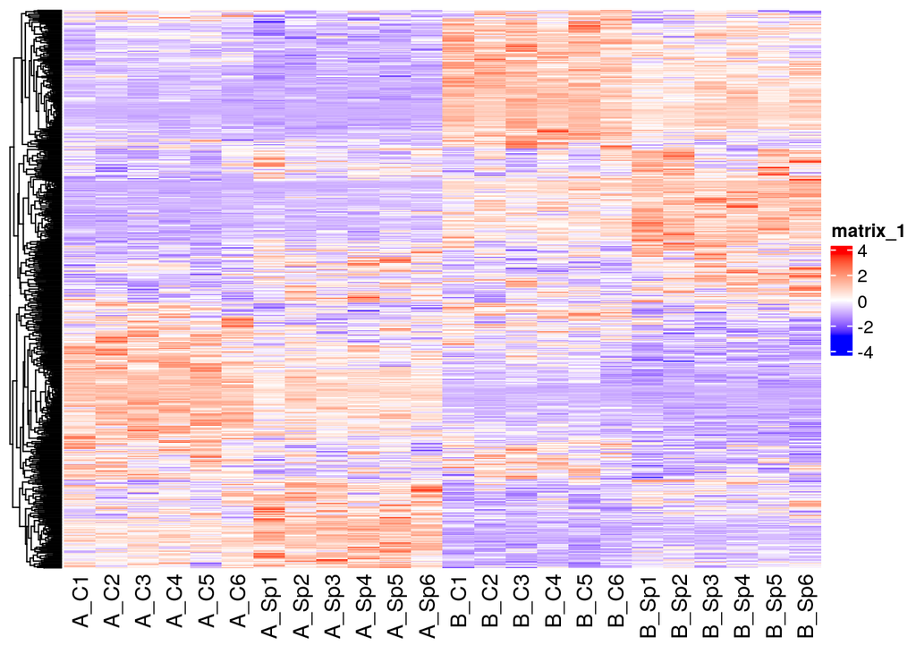

```r
top_hits <- output_hits$gene[output_hits$P.Value < 0.05]
dark_matter <- setdiff(top_hits, genes_sig_enr_gs)
dark_matter_ensembl <- output_hits$Row.names[output_hits$gene %in% dark_matter]
heatmap_matrix_tophits <- t(scale(t(normalized_counts[which(rownames(normalized_counts) %in% dark_matter_ensembl),])))
heatmap_col <- circlize::colorRamp2(c(min(heatmap_matrix_tophits), 0, max(heatmap_matrix_tophits)), c("blue", "white", "red"))
heatmap <- ComplexHeatmap::Heatmap(as.matrix(heatmap_matrix_tophits),
  cluster_rows = TRUE, show_row_dend = TRUE,
  cluster_columns = FALSE,show_column_dend = FALSE,
  col=heatmap_col,show_column_names = TRUE,
  show_row_names = FALSE,show_heatmap_legend = TRUE)
heatmap
```

heatmap of any significant genes that are not annotated to any pathways in entire set of pathways used for the analysis.

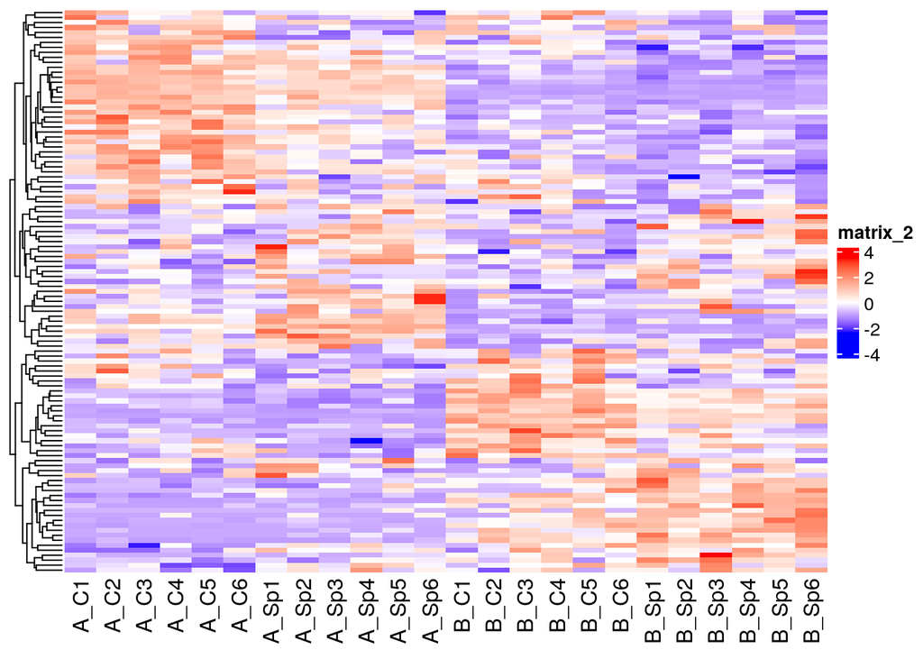

```r
top_hits <- output_hits$gene[output_hits$P.Value < 0.05]
dark_matter <- setdiff(top_hits, genes_all_gs)
dark_matter_ensembl <- output_hits$Row.names[output_hits$gene %in% dark_matter]
heatmap_matrix_tophits <- t(scale(t(normalized_counts[which(rownames(normalized_counts) %in% dark_matter_ensembl),])))
heatmap_col <- circlize::colorRamp2(c(min(heatmap_matrix_tophits), 0, max(heatmap_matrix_tophits)), c("blue", "white", "red"))
heatmap <- ComplexHeatmap::Heatmap(as.matrix(heatmap_matrix_tophits),
  cluster_rows = TRUE, show_row_dend = TRUE,
  cluster_columns = FALSE,show_column_dend = FALSE,
  col=heatmap_col,show_column_names = TRUE,
  show_row_names = FALSE,show_heatmap_legend = TRUE)
heatmap
```

## References

GeneSetEnrichmentAnalysisWiki. Data formats. 2020. Retrieved 2022 Apr 5 from https://software.broadinstitute.org/cancer/software/gsea/wiki/index.php/Data_formats

Isserlin R. Enrichment Map Analysis Pipeline. 2020. Retrieved 2022 Apr 5 from https://baderlab.github.io/Cytoscape_workflows/EnrichmentMapPipeline/Protocol2_createEM.html

Merico D, Isserlin R, Stueker O, Emili A, Bader GD. Enrichment map: a network-based method for gene-set enrichment visualization and interpretation. PLoS One. 2010 Nov 15;5(11):e13984. doi: 10.1371/journal.pone.0013984. PMID: [21085593](https://pubmed.ncbi.nlm.nih.gov/21085593/); PMCID: PMC2981572.

Morris JH, Apeltsin L, Newman AM, Baumbach J, Wittkop T, Su G, Bader GD, Ferrin TE. clusterMaker: a multi-algorithm clustering plugin for Cytoscape. BMC Bioinformatics. 2011 Nov 9;12:436. doi: 10.1186/1471-2105-12-436. PMID: [22070249](https://pubmed.ncbi.nlm.nih.gov/22070249/); PMCID: PMC3262844.

Oesper L, Merico D, Isserlin R, Bader GD. WordCloud: a Cytoscape plugin to create a visual semantic summary of networks. Source Code Biol Med. 2011 Apr 7;6:7. doi: 10.1186/1751-0473-6-7. PMID: [21473782](https://pubmed.ncbi.nlm.nih.gov/21473782/); PMCID: PMC3083346.

Rahman M, Irmler M, Keshavan S, Introna M et al. Differential Effect of SARS-CoV-2 Spike Glycoprotein 1 on Human Bronchial and Alveolar Lung Mucosa Models: Implications for Pathogenicity. Viruses 2021 Dec 17;13(12). PMID: [34960806](https://pubmed.ncbi.nlm.nih.gov/34960806/)

Reimand J, Isserlin R, Voisin V, Kucera M, Tannus-Lopes C, Rostamianfar A, Wadi L, Meyer M, Wong J, Xu C, Merico D, Bader GD. Pathway enrichment analysis and visualization of omics data using g:Profiler, GSEA, Cytoscape and EnrichmentMap. Nat Protoc. 2019 Feb;14(2):482-517. doi: 10.1038/s41596-018-0103-9. PMID: [30664679](https://pubmed.ncbi.nlm.nih.gov/30664679/); PMCID: PMC6607905.

Shannon P, Markiel A, Ozier O, Baliga NS, Wang JT, Ramage D, Amin N, Schwikowski B, Ideker T. Cytoscape: a software environment for integrated models of biomolecular interaction networks. Genome Res. 2003 Nov;13(11):2498-504. doi: 10.1101/gr.1239303. PMID: [14597658](https://pubmed.ncbi.nlm.nih.gov/14597658/); PMCID: PMC403769.

1. Allaire J, Xie Y, McPherson J, Luraschi J, Ushey K, Atkins A, et al. Rmarkdown: Dynamic documents for r. 2021.

2. Xie Y, Dervieux C, Riederer E. R markdown cookbook. Boca Raton, Florida: Chapman; Hall/CRC; 2020.

3. Zhu Y, Davis S, Stephens R, Meltzer PS, Chen Y. GEOmetadb: Powerful alternative search engine for the gene expression omnibus. Bioinformatics (Oxford, England). 2008;24:2798–800.

4. Davis S, Meltzer P. GEOquery: A bridge between the gene expression omnibus (GEO) and BioConductor. Bioinformatics. 2007;14:1846–7.

5. Durinck S, Moreau Y, Kasprzyk A, Davis S, De Moor B, Brazma A, et al. BioMart and bioconductor: A powerful link between biological databases and microarray data analysis. Bioinformatics. 2005;21:3439–40.

6. Robinson MD, McCarthy DJ, Smyth GK. edgeR: A bioconductor package for differential expression analysis of digital gene expression data. Bioinformatics. 2010;26:139–40.

7. Xie Y. Knitr: A general-purpose package for dynamic report generation in r. 2021.

8. Ritchie ME, Phipson B, Wu D, Hu Y, Law CW, Shi W, et al. limma powers differential expression analyses for RNA-sequencing and microarray studies. Nucleic Acids Research. 2015;43:e47.

9. Gu Z, Gu L, Eils R, Schlesner M, Brors B. Circlize implements and enhances circular visualization in r. Bioinformatics. 2014;30:2811–2.

10. Gu Z, Eils R, Schlesner M. Complex heatmaps reveal patterns and correlations in multidimensional genomic data. Bioinformatics. 2016.

11. Efron B, Tibshirani R. GSA: Gene set analysis. 2019.

12. Chen H. VennDiagram: Generate high-resolution venn and euler plots. 2021.

## Journal

[GitHub wiki](https://github.com/bcb420-2022/Kevin_Lu/wiki/Assignment-3)